# Air Quality in Modesto, from 2014 ’til Now

Jason Chhay

9/30/2020

#### [Back to projects page](https://jwchhay.github.io/projects.html)

## TL;DR Fire makes air bad.

For this past summer, I’ve been running outside frequently enough that I got used to the painfully hot summers of the Central Valley. Unfortunately, the California wildfires have gone rampant and nearly made it suicide to even be outside. Thus, I stayed inside.

Since the air was practically poison at this point, I sat down in my house and thought about the wildfires in general. I haven’t been home in a while, but I’m pretty sure fires haven’t really been an issue here very much.

So, I decided to look at aqicn.org to view some historical air quality data. Particulates smaller than 2.5 micrometers (PM2.5) come from fires and emissions (https://www.cdc.gov/air/particulate_matter.html), and they’re bad to inhale. I thought it would be interesting to visualize how the air has been from fires. My initial assumption is that any big peaks in PM2.5 would be from nearby wildfires.

I found data for Modesto’s air quality, which ranges from the first day of 2014 up until today, which for me is 9/30/2020. I then plotted the max PM2.5 per month, just to immediately see any big fires that happened nearby.

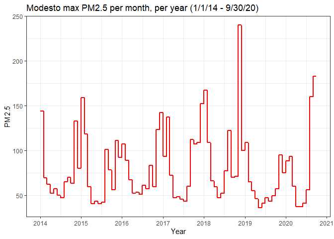

I kinda forgot there was a big fire in late 2018 (https://en.wikipedia.org/wiki/2018_California_wildfires). I was in Los Angeles at that time, so maybe that’s why I didn’t remember.

Now looking at the PM2.5 per day:

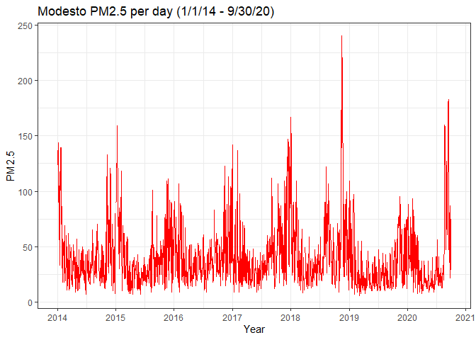

Just from observation, we can see the air looking pretty bad recently, as evident of the spike. This graph also makes me wonder if air quality is generally better in summer than in the winter time (notice the waviness). The only thing I can guess that affects wildfires and their occurrence is how much rain falls throughout the year. Dry seasons can easily cause fires to ignite and spread rampantly.

I’m not too familiar with time series analysis yet, so I’ll just leave it as this for now. Just an interesting observation, this is.